# Predicting Horror Movie Ratings from Posters and Descriptions with the Keras Functional API

Yasin Khadem Charvadeh

Do you find yourself selecting films based solely on their posters or plot summaries? I frequently catch myself browsing Netflix and making viewing decisions based purely on visual appeal or intriguing descriptions. This observation sparked my curiosity: can we quantitatively determine whether a movie's promotional materials, specifically poster imagery and plot descriptions, correlate with audience reception?

This analysis examines the relationship between movies' visual and textual marketing elements and their average ratings. The study utilizes the "Horror Movies" dataset from the TidyTuesday repository, encompassing horror films spanning from the 1950s to the present day. The dataset includes comprehensive metadata covering various film attributes, with particular focus on plot descriptions and poster imagery.

To investigate this relationship, I've developed a multimodal predictive model using Keras Functional API. This approach allows for the simultaneous processing of both textual data (movie descriptions) and visual data (poster images), combining these disparate input types to predict average movie ratings.

## Import the dataset

```r
setwd("C:/Users/yasin/Desktop/Deep learning/Horror_Movie")

library(tidyverse)
library(tensorflow)
library(keras)
library(imager)

horror_movies <- readr::read_csv('https://raw.githubusercontent.com/rfordatascience/tidytuesday/master/data/2022/2022-11-01/horror_movies.csv')


## To be able to trust the average rating, we discard entries with less than 100 vote count. I believe 100 vote count is not large enough to secure valid results, but since we do not have enough observations, we assume 100 to be a reasonable limit

horror_movies <- horror_movies %>%
  filter(vote_count >= 100)

## Append the poster path to the following url. Use the url to download the movie images

mod_horror_movies <- horror_movies %>%
  mutate(poster_path = paste0("https://image.tmdb.org/t/p/w1280/", poster_path))
```

```r
for(i in seq_len(nrow(mod_horror_movies))) {
  download.file(mod_horror_movies$poster_path[i],
                paste0(as.character(i), '.jpg'),
                mode = 'wb')
}

## Reduce the size of the images

new_path <-
  "C:/Users/yasin/Desktop/Deep learning/Horror_Movie/Images/"

for (i in seq_len(nrow(mod_horror_movies))) {
  img <- load.image(paste0(as.character(i), ".jpg"))

  pic <- resize(img, round(width(img) / 5), round(height(img) / 5))

  imager::save.image(pic, paste0(new_path, as.character(i), ".jpg"))

}
```

```r
## Unite text columns

mod_horror_movies <- mod_horror_movies %>%
  unite("full_description",
        c(title, overview, tagline),
        remove = FALSE,
        sep = " ")
```

I will not run the following chunk of code to save some space. I will, however, load the resulted preprocessed data in the next chunk.

```r
setwd("C:/Users/yasin/Desktop/Deep learning/Horror_Movie/Images")

## Load, resize, and normalize the images

pre_process <- function(temp) {
  img <- lapply(temp, image_load)
  arr <- lapply(img, image_to_array)
  arr_resized <- lapply(arr,
                        image_array_resize,
                        height = 100,
                        width = 100)
  arr_normalized <- keras::normalize(arr_resized)
  return(arr_normalized)
}

temp <- list.files(pattern = "*.jpg")

mypic <- pre_process(temp)

str(mypic)

mypic_reshaped <- array_reshape(mypic, c(nrow(mypic), 100, 100, 3))

str(mypic_reshaped)
```

```r
mypic_reshaped <- readRDS("mypic_reshaped.RDS")

## Split the preprocessed image dataset into training, validation, and test subsets

index_set <- 1:2247
train_random <- sample(index_set, 1400)
valid_random <- sample(index_set[!(1:2247 %in% train_random)], 800)
test_random <- index_set[-c(train_random, valid_random)]

train_ds_jpg <- mypic_reshaped[train_random,,,]

valid_ds_jpg <- mypic_reshaped[valid_random,,,]

test_ds_jpg <- mypic_reshaped[test_random,,,]
```

```r
## Select the outcome, vote_average, and the new text column, full_description. Split the dataset into training, validation, and test subsets

train_ds <- mod_horror_movies %>%
  select(full_description, vote_average) %>%
  slice(train_random)

valid_ds <- mod_horror_movies %>%
  select(full_description, vote_average) %>%
  slice(valid_random)

test_ds <- mod_horror_movies %>%
  select(full_description, vote_average) %>%
  slice(test_random)

## Use the Keras layer_text_vectorization() to prepare the text data
## layer_text_vectorization() is used to convert to lowercase and remove punctuation, standardize the text, and split on whitespace for tokenization.

## output_mode is "count" here which returns count of the number of times tokens appear in the batch item. There are other output modes such as "tf-idf", "int", etc.

text_vectorization <- layer_text_vectorization(max_tokens = 1500,
                                               output_mode = "count")

## Index the vocabulary of the text corpus using adapt() function

adapt(text_vectorization, train_ds$full_description)

## Prepare processed versions of our training, validation, and test datasets

int_token_train_ds <- train_ds$full_description %>%
  text_vectorization()

int_token_valid_ds <- valid_ds$full_description %>%
  text_vectorization()

int_token_test_ds <- test_ds$full_description %>%
  text_vectorization()

## Specify input layer for text data

text_input <-
  layer_input(shape = c(1500), name = "txt")

## Specify input layer for image data

image_input <- layer_input(shape = c(100, 100, 3), name = "jpg")

## Use layer_conv_2d() and layer_max_pooling_2d() to create convolution layer and perform downsampling to reduce the number of feature-map coefficients

image_features <- image_input %>%
  layer_conv_2d(
    filter = 32,
    kernel_size = c(3, 3),
    padding = "same",
    activation = "relu"
  ) %>%
  layer_conv_2d(
    filter = 16,
    kernel_size = c(3, 3),
    padding = "same",
    activation = "relu",
    kernel_regularizer = regularizer_l2(0.2)
  ) %>%
  layer_max_pooling_2d(pool_size = c(2, 2)) %>%
  layer_flatten() %>%
  layer_dense(42,
              activation = "relu",
              kernel_regularizer = regularizer_l2(0.4))

## Use layer_concatenate to concatenate the branches of the network (combine two inputs)
## Add a dense layer to recombine input features into richer representations

features <- layer_concatenate(c(text_input, image_features)) %>%
  layer_dense(64,
              activation = "relu",
              kernel_regularizer = regularizer_l2(0.5))

## Define the output layer. No activation function indicates a continuous output

My_output <- features %>% layer_dense(1)

## Use keras_model() to combine input and output into one model, and then compile and fit

model <- keras_model(inputs = list(text_input, image_input),
                     outputs = My_output)

model %>% compile(
  optimizer = optimizer_rmsprop(learning_rate = 0.0001, decay = 1e-6),
  loss = c("mean_squared_error"),
  metrics = c("mae")
)

model
```

```
## Model: "model"
## ________________________________________________________________________________
##  Layer (type)             Output Shape      Param #  Connected to
## ================================================================================
##  jpg (InputLayer)         [(None, 100, 100  0        []
##                           , 3)]
##  conv2d_1 (Conv2D)        (None, 100, 100,  896      ['jpg[0][0]']
##                            32)
##  conv2d (Conv2D)          (None, 100, 100,  4624     ['conv2d_1[0][0]']
##                            16)
##  max_pooling2d (MaxPoolin  (None, 50, 50, 1  0       ['conv2d[0][0]']
##  g2D)                     6)
##  flatten (Flatten)        (None, 40000)     0        ['max_pooling2d[0][0]']
##  txt (InputLayer)         [(None, 1500)]    0        []
##  dense (Dense)            (None, 42)        1680042  ['flatten[0][0]']
##  concatenate (Concatenate  (None, 1542)     0        ['txt[0][0]',
##  )                                                    'dense[0][0]']
##  dense_1 (Dense)          (None, 64)        98752    ['concatenate[0][0]']
##  dense_2 (Dense)          (None, 1)         65       ['dense_1[0][0]']
## ================================================================================
## Total params: 1,784,379
## Trainable params: 1,784,379
## Non-trainable params: 0
## ________________________________________________________________________________
```

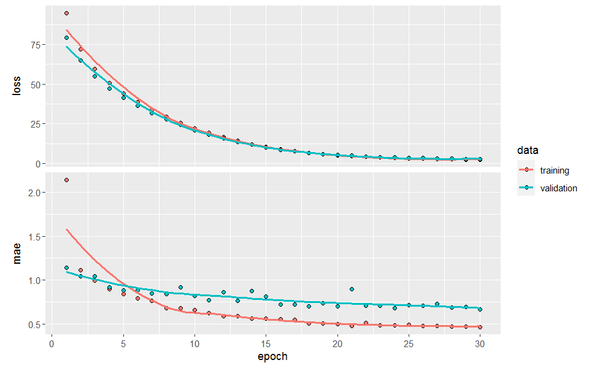

```r
## Normalize the text input

normalizer <- layer_normalization(axis = -1L)
normalizer %>% adapt(as.matrix(int_token_train_ds))

txt_x_train <- normalizer(int_token_train_ds)
jpg_x_train <- train_ds_jpg

txt_x_valid <- normalizer(int_token_valid_ds)
jpg_x_valid <- valid_ds_jpg

txt_x_test <- normalizer(int_token_test_ds)
jpg_x_test <- test_ds_jpg

## Fit the model
## There exist some random fluctuation in the validation mae pattern. This pattern is most likely due to small validation sample size or maybe over-regularization

f_model <- model %>% fit(
  x = list(txt_x_train, jpg_x_train),
  y = as.matrix(mod_horror_movies$vote_average[train_random]),
  validation_data = list(
    x = list(txt_x_valid, jpg_x_valid),
    y = as.matrix(mod_horror_movies$vote_average[valid_random])
  ),
  epochs = 30,
  batch_size = 50
)

plot(f_model)
```

```r
## Evaluate the model on the test set. Considering the fact that our sample size is not that large, the performance of the model is not too bad!
## Certainly more samples are needed to evaluate the performance more accurately!

model %>% evaluate(
  x = list(txt_x_test, jpg_x_test),
  y = as.matrix(mod_horror_movies$vote_average[test_random])
)
```

```
##      loss       mae
## 2.5166390 0.5667349
```

```r
predicted_values <- model %>% predict(list(txt_x_test, jpg_x_test))

## Predicted vs Observed

bind_cols(predicted_values = predicted_values,
          true_values = mod_horror_movies$vote_average[test_random])
```

```
## # A tibble: 47 x 2
##    predicted_values[,1] true_values
##                   <dbl>       <dbl>
##  1                 5.86         5.7
##  2                 5.84         5.6
##  3                 5.80         5.6
##  4                 6.15         5.6
##  5                 6.30         6.1
##  6                 6.17         7.3
##  7                 5.75         6.7
##  8                 5.89         6.3
##  9                 5.59         5.9
## 10                 5.35         6.9
## # ... with 37 more rows
```